# Project 2B: A Midsummer Light’s Dream

Maya Renter

Saturday, May 07, 2022 @ 08:47 PM

**Note:** Use tidyverse functions whenever possible for manipulating/summarizing data and for plotting. Except for plots used specifically to assess normality, all plots should have appropriate titles and axis labels. If you have a partial code attempt that prevents your Markdown from compiling to HTML, comment out the code so `R` will not try to compile it but I can still see your efforts.

**Names of Collaborators**

Names: Breanna Jones

### Setup

#### Packages Used

Load all packages used in this project.

```r
library(tidyverse)
library(infer)
library(HistData)
Michelson
```

[output not shown]

[output cut: 86 more lines]

### Analysis

#### Background

Albert Michelson (1852–1931) was an American physicist known for his work on measuring the speed of light. He was the first American to win the Nobel Prize for science (1907). The `Michelson` dataset from the HistData package contains experimental measurements of the velocity of light in air, which Michelson gathered from June 5 to July 2, 1879 and reported in [Michelson (1882)](https://www.gutenberg.org/files/11753/11753-h/11753-h.htm). The reported data values plus 299,000 are Michelson’s actual experimental measurements in km/sec—he subtracted 299,000 to make his subsequent calculations easier to do by hand. To compensate for refraction due to air temperature when he estimated the speed of light in air, Michelson added 12 km/sec to the data. When further estimating for the speed of light in a vacuum, he added an additional refraction correction of 80 km/sec. Variability in the data observations is assumed to be caused by the experimental equipment and method, so the mean of the measurements is used to estimate the velocity.

Currently accepted values for the velocity of light are 299,792.458 km/sec in a vacuum and 299,702.547 km/sec in air. The ratio of these two values is 1.0003, or three ten-thousandths of the velocity of light in a vacuum.

Reportedly, when asked why he chose to study light, Michelson once said, “because it’s so much fun.”

You will estimate the velocity of light from Michelson’s experimental data, using interval estimates not yet developed in his time.

#### **Modify the Dataset**

Use `glimpse()` to visualize the dataset.

```r
glimpse(Michelson)
```

```
Rows: 100
Columns: 1
$ velocity <int> 850, 740, 900, 1070, 930, 850, 950, 980, 980, 880, 1000, 980,…
```

Create new variables in the dataset to represent Michelson’s corrections to his data. Then `glimpse()` the revised dataset.

- `vel_air` = add 12 to the observed `velocity` values to get the temperature-corrected velocity in air
- `vel_vac` = add 80 to the corrected velocity in air to get the refraction-corrected velocity in a vacuum

```r
michelsonmodified <- Michelson %>%
  mutate(vel_air = velocity + 12,
         vel_vac = vel_air + 80)

glimpse(michelsonmodified)
```

```
Rows: 100
Columns: 3
$ velocity <int> 850, 740, 900, 1070, 930, 850, 950, 980, 980, 880, 1000, 980,…
$ vel_air  <dbl> 862, 752, 912, 1082, 942, 862, 962, 992, 992, 892, 1012, 992,…
$ vel_vac  <dbl> 942, 832, 992, 1162, 1022, 942, 1042, 1072, 1072, 972, 1092, …
```

```r
#Sample Means
meanvelair<- mean(michelsonmodified$vel_air)
meanvelvac <- mean(michelsonmodified$vel_vac)
```

#### **Exploration 1: Exploratory Data Analysis**

The first step before doing any estimation is to conduct exploratory data analysis (EDA). Use the original `velocity` data.

##### Calculate the sample mean, standard deviation, skewness, and kurtosis.

```r
# Sample Mean and Standard Deviation
xbar <- mean(michelsonmodified$velocity)
s <- sd(michelsonmodified$velocity)
s
```

```
[1] 79.01055
```

```r
# Skewness
library(moments)
tibble(statistic = c("Skewness", "Kurtosis", "Excess K"),
       theory    = c(0, 3, 0),
       data      =
         c(skewness(michelsonmodified$velocity),
           kurtosis(michelsonmodified$velocity),
           kurtosis(michelsonmodified$velocity) - 3))
```

```
# A tibble: 3 × 3
  statistic theory    data
  <chr>      <dbl>   <dbl>
1 Skewness       0 -0.0183
2 Kurtosis       3  3.26
3 Excess K       0  0.264
```

##### Create a histogram of the data. Include an appropriate number of bins.

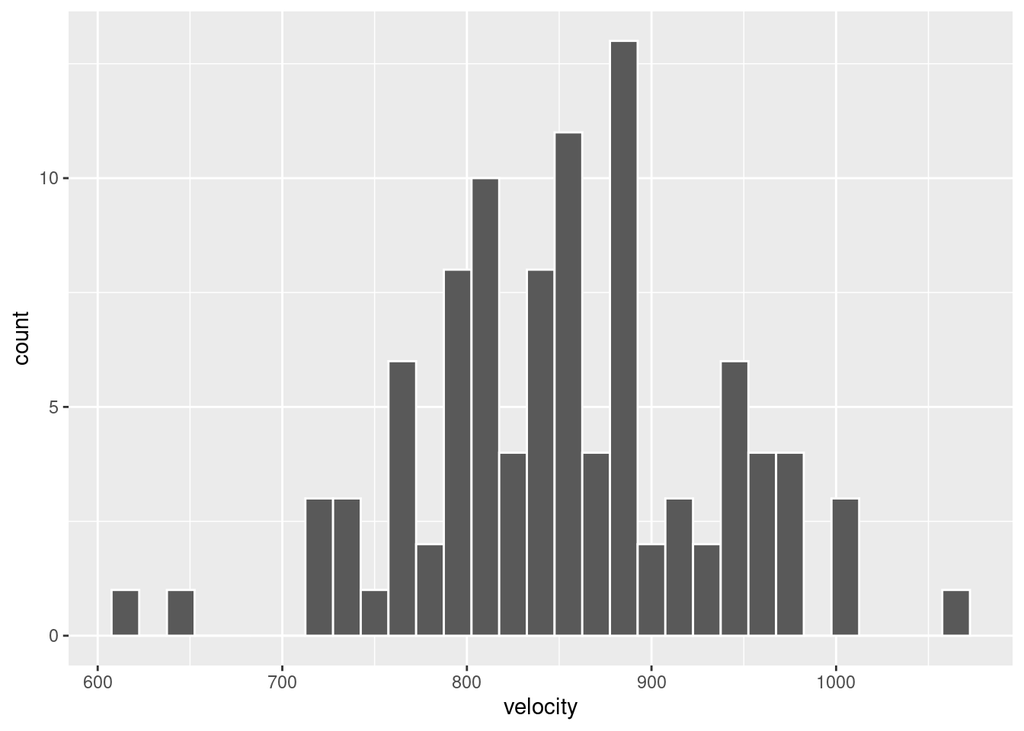

```r
ggplot(michelsonmodified, aes(x = velocity)) +
  geom_histogram(binwidth = 15, color = "white")
```

##### Create a boxplot of the data. Use `outlier.color =` to highlight outliers.

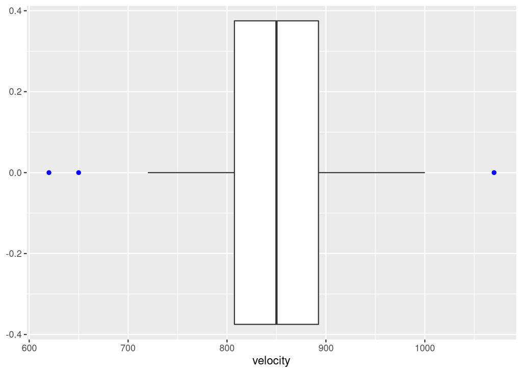

```r
ggplot(michelsonmodified, aes(x = velocity)) +
  geom_boxplot(outlier.color ="blue")
```

##### Create a normal QQ plot of the data a reference line in a different color.

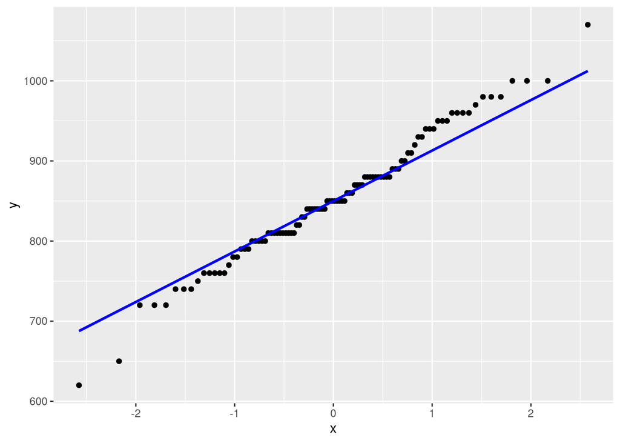

```r
ggplot(michelsonmodified, aes(sample = velocity)) +
  stat_qq() +
  stat_qq_line(
    color = "blue",
    size = 1.0
  )
```

#### **Exploration 2: Traditional 95% Confidence Interval**

Calculate a traditional 95% confidence interval for the velocity of light in air and in vacuum.

```r
velvac_data <- michelsonmodified %>%
  select(vel_vac)
glimpse(velvac_data)
```

```
Rows: 100
Columns: 1
$ vel_vac <dbl> 942, 832, 992, 1162, 1022, 942, 1042, 1072, 1072, 972, 1092, 1…
```

```r
velair_data <- michelsonmodified %>%
  select(vel_air)
glimpse(velair_data)
```

```
Rows: 100
Columns: 1
$ vel_air <dbl> 862, 752, 912, 1082, 942, 862, 962, 992, 992, 892, 1012, 992, …
```

##### Velocity of Light in Air

```r
t.test(velair_data, conf.level = .95)
```

```
    One Sample t-test

data:  velair_data
t = 109.4, df = 99, p-value < 2.2e-16
alternative hypothesis: true mean is not equal to 0
95 percent confidence interval:
 848.7226 880.0774
sample estimates:
mean of x
    864.4
```

##### Velocity of Light in Vacuum

```r
t.test(velvac_data, conf.level = .95)
```

```
    One Sample t-test

data:  velvac_data
t = 119.53, df = 99, p-value < 2.2e-16
alternative hypothesis: true mean is not equal to 0
95 percent confidence interval:
 928.7226 960.0774
sample estimates:
mean of x
    944.4
```

#### **Exploration 3: Bootstrap 95% Percentile Interval**

Calculate a bootstrap 95% percentile interval for the velocity of light in air and in vacuum.

##### Velocity of Light in Air

```r
velair_data %>%
  get_confidence_interval(level = 0.95, type = "percentile")
```

```
# A tibble: 1 × 2
  lower_ci upper_ci
     <dbl>    <dbl>
1      732     1012
```

##### Velocity of Light in Vacuum

```r
velvac_data %>%
  get_confidence_interval(level = 0.95, type = "percentile")
```

```
# A tibble: 1 × 2
  lower_ci upper_ci
     <dbl>    <dbl>
1      812     1092
```

#### **Exploration 4: Bootstrap 95% Standard Error Interval**

Calculate a bootstrap 95% standard error interval for the velocity of light in air and in vacuum.

##### Velocity of Light in Air

```r
velair_data %>%
   get_confidence_interval(type = "se", point_estimate = velair_data, level=0.95)
```

```
# A tibble: 1 × 2
  lower_ci upper_ci
     <dbl>    <dbl>
1     707.    1017.
```

##### Velocity of Light in Vacuum

```r
velvac_data %>%
   get_confidence_interval(type = "se", point_estimate = velvac_data, level=0.95)
```

```
# A tibble: 1 × 2
  lower_ci upper_ci
     <dbl>    <dbl>
1     787.    1097.
```

### Questions

#### **Question 1: Interval Assumptions**

Are all of the necessary assumptions met for each of the three interval estimation methods you used? Discuss using logic and evidence from your exploratory data analysis.

#### **Question 2: The “True” Velocities**

Do any of the interval estimates you created contain the currently accepted “true” values for the velocity of light in air and in vacuum? If not, why do you think the estimation “failed”? Discuss.

Reference: Michelson, A. A. (1882). “Experimental determination of the velocity of light made at the United States Naval Academy, Annapolis”. *Astronomical Papers*, 1, 109-145, U. S. Nautical Almanac Office.